# Assignment 5

#### **Exercise 1:** Thoughts on the here::here Package

Accessibility to your work when using Rstuido allows for better collaboration and obtaining help from other R users. Frustration arises from those who by default start the scripts with setwd() and rm(list = ls()) at the beginning of their scripts due to the fact that in order for someone else to access the files if they rewirte the *exact* path on their computer this is partially due to the fact that the rules that dictate file paths between operating systems are not harmonious. Jenny Byran recommends to use the here::here package as it more robust than simply just working with R projects which she still recommends to do also. The here package creates relative file paths, avoiding the language barrier between operating systems. Even if you are not in the directory, here() can find the working directory. Manipulated data to produce a new table or figure could also be saved in different subdirectories without having to change the relative directory. Another great benefit of here is that files can still run outside of Rstudio.

## **Exercise 2:** Factor Management

```r
gapminder
```

The variables that are factors in the gapminder dataset are **country** and **continent**. Observations assoicated with “Ocenia” will be removed along with unused factor levels.

To compare how dropping factors and using arange affects data, the tibble with the dropped factors will be dubbded as “gap.”

```r
gap= gapminder %>%
  filter(continent %in% c("Africa", "Asia", "Europe", "Americas")) %>%
  droplevels()
levels(gap$continent)
```

```
## [1] "Africa"   "Americas" "Asia"     "Europe"
```

```r
  # should have some code here to display that it worked...
```

Going to look at total GDP for the year 1997

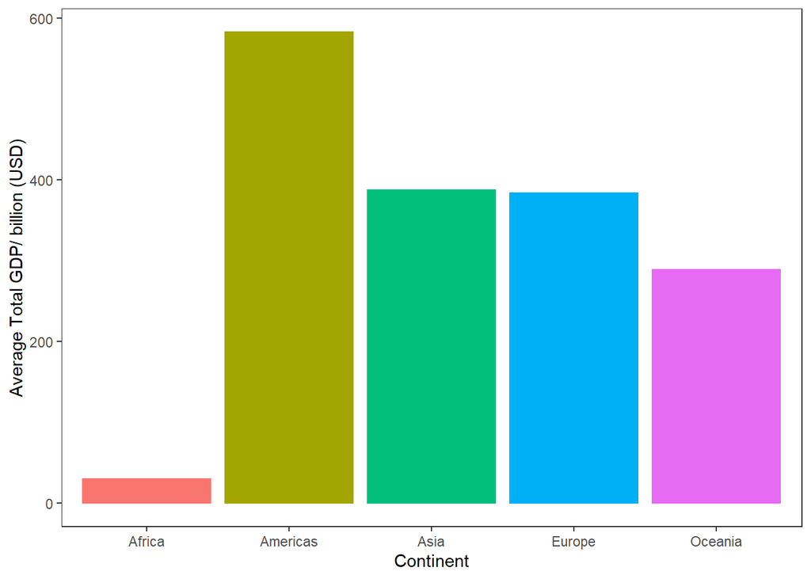

```r
gapminder %>%
  filter(year == 1997) %>%
  mutate(gdpTotal = gdpPercap*pop) %>%
  group_by(continent) %>%
  summarize(av_gdpTotal = mean(gdpTotal)/1000000000) %>%
  ggplot(aes(continent, av_gdpTotal, colour = continent, fill = continent)) +
  geom_histogram(stat="identity") +
  theme_bw() +
  theme(panel.grid.major = element_blank(),
        panel.grid.minor = element_blank(),
        legend.position = "none") +
  xlab("Continent") +
  ylab("Average Total GDP/ billion (USD)")
```

## **Exercise 3 :** File Input/Output

The manipulated data from exercise 2 was written and read using write.csv and read.csv respectively along with here::here().

```r
gap97 <- gap %>%
  filter(year == 1997) %>%
  mutate(gdpTotal = gdpPercap*pop)
```

```r
write.csv(gap97, here::here("Hw05", "gap97b.csv"))
```

```r
gap97b <- read.csv(here::here("Hw05", "gap97b.csv"))
```

```r
gap97b %>%
  select(country, gdpTotal) %>%#summarized
DT::datatable()
```

|  | country | gdpTotal |
| --- | --- | --- |
| 1 | Afghanistan | 14121995875.3377 |
| 2 | Albania | 10945912518.587 |
| 3 | Algeria | 139467033682.098 |
| 4 | Angola | 22486820880.8812 |
| 5 | Argentina | 397053586287.393 |
| 6 | Austria | 234800471832.038 |
| 7 | Bahrain | 12146009861.8392 |
| 8 | Bangladesh | 119957417048.458 |
| 9 | Belgium | 281118335091.118 |
| 10 | Benin | 7479326759.29536 |

[output cut: 130 more lines]

**Success.**

Currently, the data is sorted alphabetically based on the factor country. I would like to sort the countries based on the GDP per Capita value.

```r
gap97 %>%
  mutate(country = fct_reorder(gdpPercap, country)) %>%
DT::datatable()
```

```
## Error: `f` must be a factor (or character vector or numeric vector).
```

```r
# What if I gdppercap and country?
```

```r
gap97 %>%
  mutate(country = fct_reorder(country, gdpPercap)) %>%
gap97$country %>%
  levels()
```

```
## Error in .$gap97: 3 arguments passed to '$' which requires 2
```

#### Need more practice with working with levels evidently

The countries were still sorted alphabetically and not based on the GDP per capita value.

## **Exercise 4:** Data Visualization

In Assignment 2 we looked at the GDP per capita versus the life expectancy of Canada. I wanted to extend the analysis to 2 other countries,, specifically China and Brazil

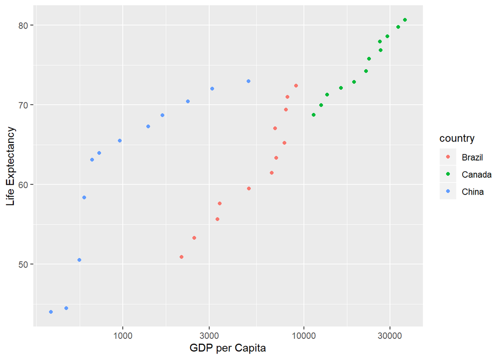

```r
gapminder %>%
  filter(country == "Canada"| country == "China" | country == "Brazil") %>% # add other countries
  ggplot(aes(gdpPercap, lifeExp, colour = country)) +
  geom_point() +
  scale_x_log10() +
  xlab("GDP per Capita") +
  ylab("Life Exptectancy")
```

I wanted to compare the trends between the 3 countries and felt that it was hard to tell the trends on the same plot. So I decided to use facet_wrap() as previously had been done in class. Also, in order to obtain more information about a point on the graph I used Plotly.

```r
#  {r, fig.width = 5, fig.height = 2}
gap3 <- gapminder %>%
  filter(country == "Canada"| country == "China" | country == "Brazil") %>%
  ggplot(aes(gdpPercap, lifeExp, fill = country, colour = country, labels = year)) +
  facet_wrap(~ country, nrow = 1) +
  geom_point(alpha = 0.5) +
  scale_x_log10(labels = scales::comma_format()) +
  xlab("GDP Per Capita") +
  ylab("Life Expectancy (Years)") +
  ggtitle(" GDP per Capita versus Life Expectancy") +
  theme(plot.title = element_text(size=16, face="bold")) +
  scale_size_area() +
  theme_bw() +
  theme(panel.grid.major = element_blank(),
        panel.grid.minor = element_blank(),
        plot.title = element_text(size=16, face="bold"),
        legend.position = "none") +
  theme(axis.title.x = element_text(vjust = -2), axis.title.y = element_text(vjust = -2)) # last ditch attempt to fix the crowded axis titles

gap3 %>%
  ggplotly()
```

[interactive chart not shown]

Save the plot to folder.

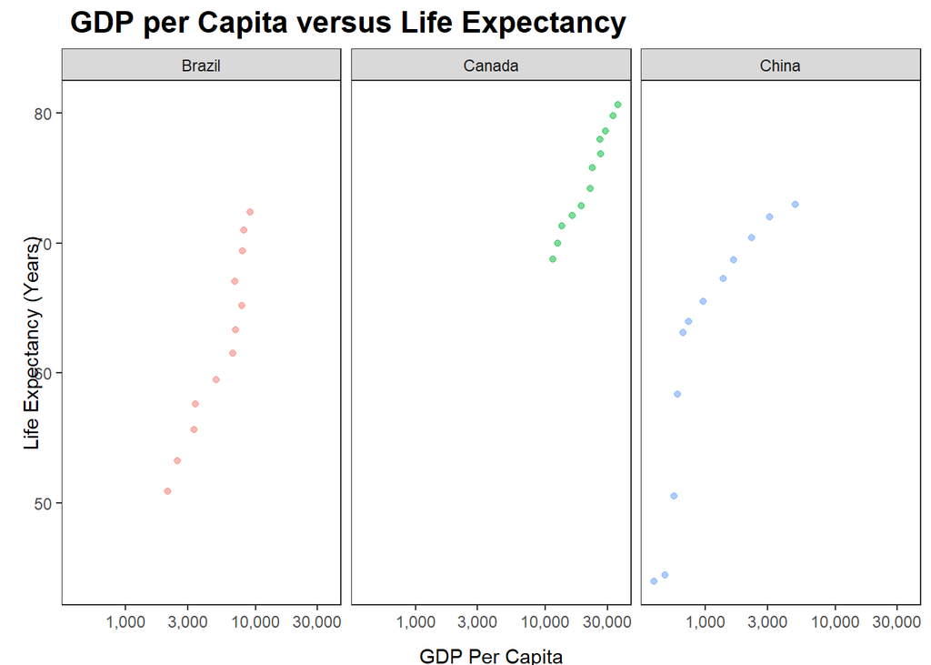

```r
gap3
```

```r
ggsave("gap3.png", width = 5.5, height = 2.5, units = "in")
# way to use here::here() package?
```

Here is a nice image than the plotly (hopefully)

[figure not shown]

GDP versus Life Expectancy for Brazil, Canada and China